# Distress in the time of COVID

RW Morris<sup>1,2</sup>, F Botha<sup>2,3</sup>, P Butterworth<sup>3</sup> & N Glozier<sup>2,4</sup> (order to be decided)

1. School of Psychology, Faculty of Science, University of Sydney, NSW, Australia
2. ARC Centre of Excellence for Children and Families over the Life Course
3. Melbourne Institute: Applied Economic & Social Research, The University of Melbourne, VIC, Australia
4. Central Clinical School, Faculty of Medicine and Health, University of Sydney, NSW, Australia

**Corresponding author:**

[output not shown]

[output not shown]

Declarations of interest: none.

Funding sources: This research was supported by the Australian Government through the Australian Research Council’s Centre of Excellence for Children and Families over the Life Course (Project ID CE200100025)

# Abstract

The effects of Australian government responses to COVID-19 (e.g., lockdowns) on economic uncertainty, psychological distress and suicide have been the subject of much modelling, debate and controversy. For instance, widely publicised models have suggested a median yearly increase in suicide rates of 9-25% – actual increases of 276-750 suicide deaths per year (Brain and Mind Centre 2020); which would mean Australia would account for almost 20 percent of the global suicide tally, which seems unlikely. A key factor in these models is the use of historical population-estimates of psychological distress acting as a final mediator of the effects of socio-economic factors such as job loss on suicide rates. However the historical temporal links between the economy, suicide and psychological distress have not been re-examined in the current pandemic, or in fact ever in Australia. [The University of Maryland Social Data Science Center Global COVID-19 Trends and Impact Survey, in partnership with Facebook](https://covidmap.umd.edu), collects daily samples of psychological distress since the beginning of the pandemic in April 2020 from Facebook users throughout Australia and its States and Territories. These daily samples represent a unique resource with which to compare against the routinely collected estimates of psychological distress by the ABS and other sources (e.g., [Taking the Pulse of the Nation](https://melbourneinstitute.unimelb.edu.au/data/covid-19-tracker)), and may also support a detailed examination of the links between psychological distress and other factors such as unemployment and suicide.

**keywords:** depression, anxiety, mental health

## 1.0 Introduction

There is much uncertainty around the immediate and long term impacts of the Coronavirus Pandemic (COVID-19) on psychological distress, economic security and suicide mortality in Australia. There is little evidence from previous pandemics as to their effects on these factors, and modelling has produced a wide range of results reflecting this uncertainty [(Tang et al 2020 Insight)](https://insightplus.mja.com.au/2020/29/covid-19-and-suicide-variation-and-response/).

Australia presents a useful case study on the effect of government policy response to the pandemic. Victoria, along with the rest of Australia, successfully reduced COVID-19 cases to negligible levels by early June of 2020 (as few as 3 new cases a day according to the 7-day trailing average, www.covid19live.com.au). However a second wave forced the State government to shut borders and reintroduce severe lockdown restrictions across Melbourne and surrounding regions in early July (July 7th). A state-of-disaster was declared on August 2nd 2020 with increased restrictions for at least six weeks. By comparison, NSW and QLD weathered 2020 with relatively few restrictions. However in 2021, Sydney and later NSW also entered an extended lockdown as the delta variant emerged, followed by Melbourne and Victoria. By the end of 2021, Melbourne and Sydney had endured 272 and 150 days of lockdown while QLD (and the rest of Australia) were relatively free of restrictions. This makes the east coast states (NSW, VIC, QLD), and Australia more widely, a good case-study to examine the impact of extended lockdowns on the prevalence of distress, depression and anxiety in the population, relative to its temporal trend as well as by comparisons between states.

## 2.0 Methods

The University of Maryland Social Data Science Center [Global COVID-19 Trends and Impact Survey](https://gisumd.github.io/COVID-19-API-Documentation/), in short form as **UMD Global CTIS**, is a partnership between Facebook Data for Good, Delphi Group at Carnegie Mellon University, the Joint Program on Survey Methodology at the University of Maryland, the Duke Margolis Center for Health Policy, and Resole to Save Lives, an initiative of Vital Strategies. A representative sample of Facebook users was invited on a daily basis to report on topics including, for example, symptoms, social distancing behavior, vaccine acceptance, mental health issues, and financial constraints ([the complete list of survey variables is available here](https://gisumd.github.io/COVID-19-API-Documentation/docs/indicators/indicators.html)). Facebook provides weights to reduce nonresponse and coverage bias.

UMD Global CTIS provides smoothed and unsmoothed aggregates in an open API. More details on the aggregated items can be found [here](https://gisumd.github.io/COVID-19-API-Documentation/docs/indicators/indicators.html). Here we present results from the microdata, which is not publically available.

#### 2.1 Sampling method

Global Facebook users were invited to take off-platform surveys of COVID-19-related symptoms beginning April 23rd, 2020. The survey and sampling strategy was designed by the University of Maryland Joint Program in Survey Methodology (Kreuter et al. 2020), and a brief description of the methods of the stratified survey collection can be found [here](https://covidmap.umd.edu/document/css_methods_brief.pdf). Every day, a new representative sample of Facebook users over 18 years old was invited to consent and participate via an invitation at the top of their Facebook News Feed and the surveys were conducted by the University of Maryland partner. Participants reported on COVID-19 symptoms, social distancing behavior, and financial constraints. The survey microdata is provided in granular form (i.e., response-level or person-specific data). Facebook provided regionally-specific weights to reduce nonresponse and coverage bias across age and gender. Thus the resulting weighted percentages can be treated as population estimates for each Australian region.

#### 2.2 Psychological distress

Psychological distress was measured by the following two questions adapted from the K10 (Kessler et al. 2003):

> “During the last 7 days, how often did you feel so depressed that nothing could cheer you up?” (*None, a little, some, most, or all of the time*).

> “During the last 7 days, how often did you feel so nervous that nothing could calm you down?” (*None, a little, some, most, or all of the time*).

We report psychological distress as the weighted percentage of people experiencing depression or anxiety “most” or “all of the time”, as well as the weighted percentage of each constituent separately as depression and anxiety respectively.

The total number of responses from Australia in 2020 and 2021 were *N* = 918,654.

#### 2.3 Financial concern (not included)

Financial concern was measured by a single item:

> “How worried are you about your household’s finances in the next month?” (*Very, somewhat, not too worried, not at all*)

We report the weighted percentage of people very or somewhat worried about their household finances in the next month.

## 3.0 Results

Lockdown periods for each state are shaded. Major dates in 2020 included the reintroduction of severe lockdown restrictions across Melbourne and surrounding regions on July 7th, 2020. A State of Emergency was declared in Victoria on August 2nd, 2020 with increased restrictions for at least six weeks. However most of the other states continued to enjoy relatively few cases and no restrictions for the remainder of the year.

#### 3.1 Psychological distress

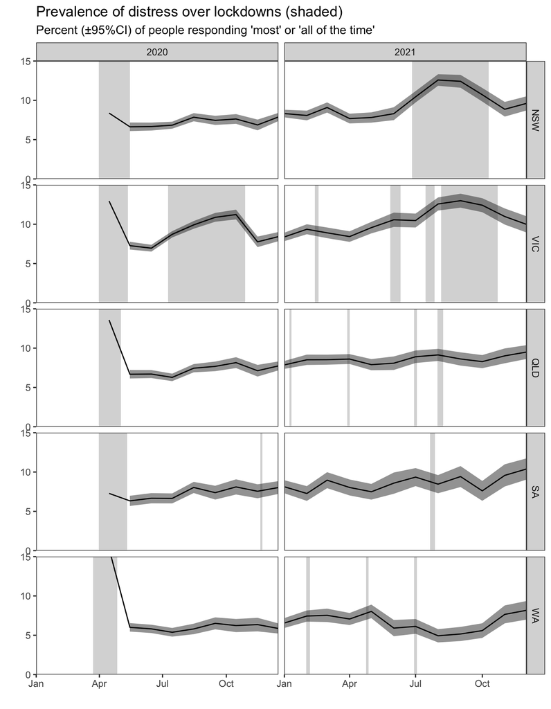

#### 3.2 Depression & anxiety

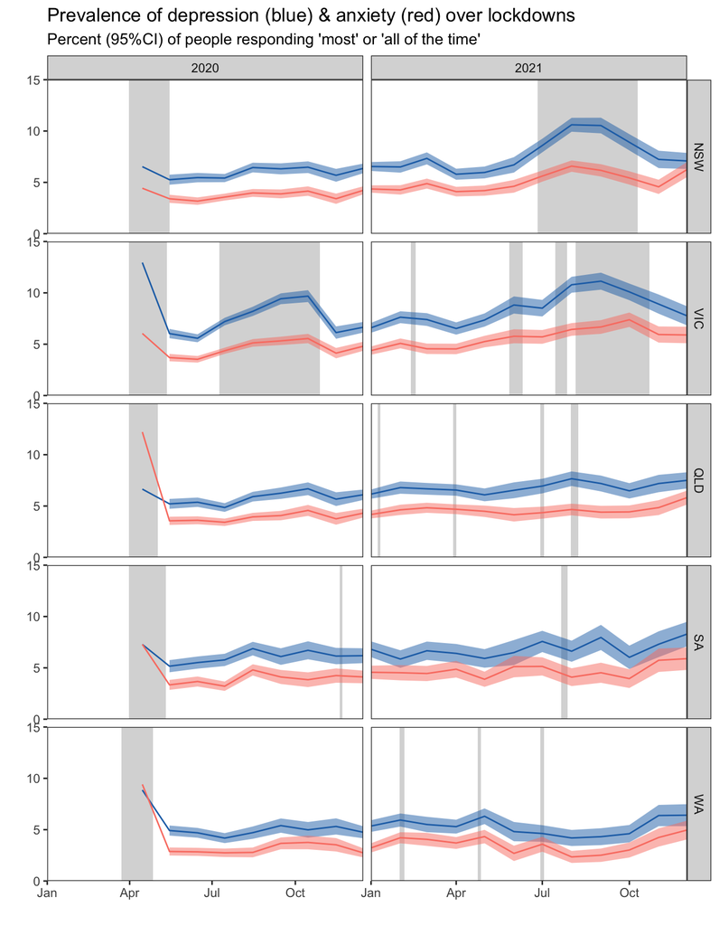

#### 3.3 Depression by age

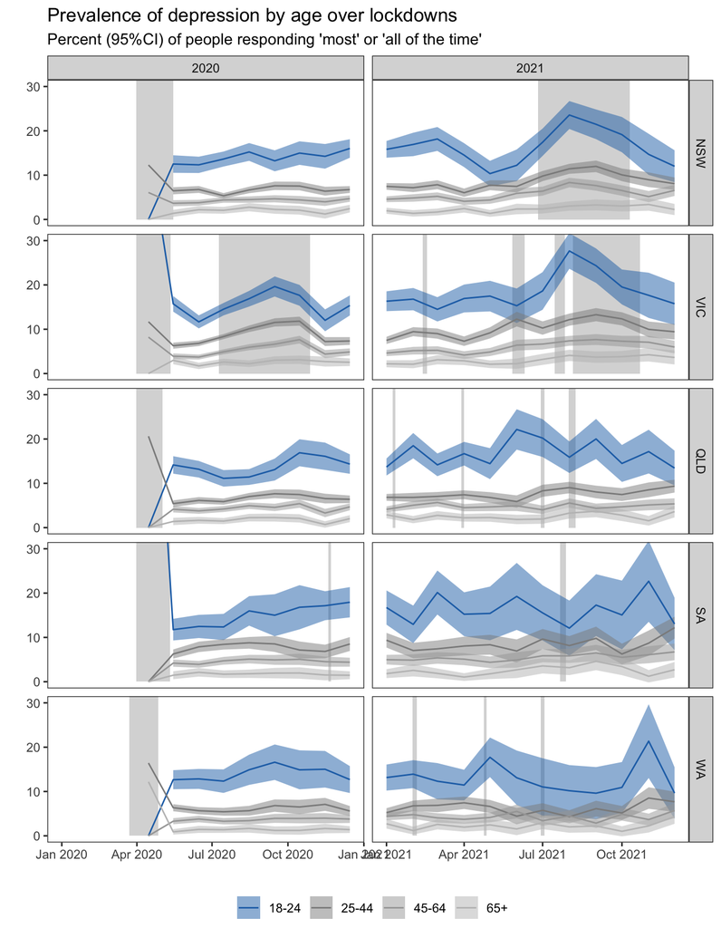

#### 3.4 Anxiety by age

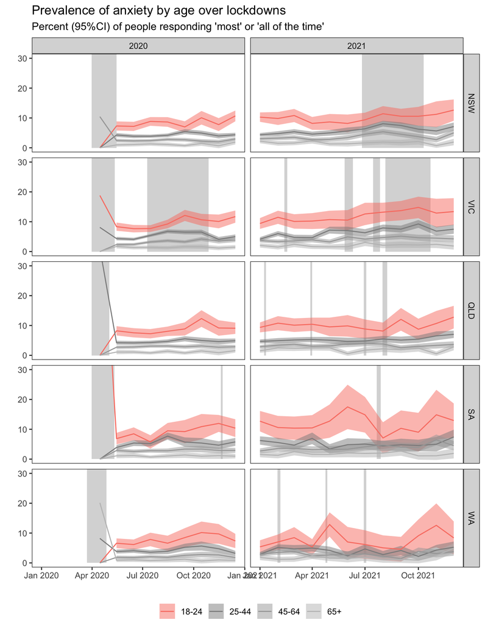

#### 3.3 Financial concern (not run)

From January 1st 2021, the Coronavirus supplement was reduced from $250 to $150/fortnight. It ended entirely on April 1st 2021.

## 5.0 References

Brain and Mind Centre. Sounding the alarm [Internet]. The University of Sydney; 2020. Available from: https://www.sydney.edu.au/content/dam/corporate/documents/brain-and-mind-centre/mental-wealth/sounding_the_alarm_usyd_ncphn.pdf

Kessler RC, Barker PR, Colpe LJ, Epstein JF, Gfroerer JC, Hiripi E, et al. Screening for serious mental illness in the general population. Archives of general psychiatry. 2003;60(2):184–9.

Kreuter F, Barkay N, Bilinski A, Bradford A, Chiu S, Eliat R, et al. Partnering with a global platform to inform research and public policy making. In: Survey research methods. 2020. pp. 159–63.